# Growth and inequality in public good provision: an extended replication

Report and analysis protocoll.

Hauke Roggenkamp https://www.ibt.unisg.ch/team/hauke-roggenkamp/ (Helmut Schmidt University)https://www.hsu-hh.de/en/ , true  
2022-10-08

**Hintergrund:** Ich habe diesen [post](https://groups.google.com/g/esa-announce/c/-_2OmbkdxEk) gesehen und überlege meine Replikation entsprechend [hier](https://www.sciencedirect.com/journal/journal-of-behavioral-and-experimental-economics/about/call-for-papers#transparency-reproducibility-and-generalizability-of-behavioral-economics-experiments) einzureichen. Ist das realistisch? Wenn ja, wie soll man die Story aufziehen? Soll man denen mal schreiben und fragen, ob noch Platz ist?

> “There are two possible articles you can write: (a) the article you planned to write when you designed your study or (b) the article that makes the most sense now that you have seen the results. They are rarely the same, and the correct answer is (b).” (Bem 1987, 171)

# Introduction

Macroeconomists understand the world as dynamic where the timing matters: Today’s savings decision affect lifetime consumption which is why it makes a difference whether you consume more today or tomorrow. Yet, experimental economists often design static games without dynamic inter-dependencies: participants face the same decisions multiple times and previous decisions do not affect current incentives of endowments.

To measure how cooperation affects growth and inequality, Gächter et al. (2017) (to whom I often refer as GMTV in what follows) extended a standard public goods game with temporal inter-dependencies.[^1] Their results show that participants behave strikingly similar as in the static games (contributions are non-zero; the share of current endowments contributed declines over time; and the initial contribution is around half of their endowments) and illustrate how this affects growth and inequality.

Because environmental and climate action (or the absence of it) is characterized by pro-social behavior and inter-temporal dynamics (the more we hesitate to cut CO2 emissions, the more expensive it will be to reach a certain target in the future), we are interested in applying this setting in a behavioral and environmental economics context with a general population sample.

Due to COVID-19 and corresponding restrictions at that time, we decided to replicate GMTV’s no punishment 10 period game to evaluate, whether it is feasible to run a multi-period, synchronous group experiment with such a sample first.

As we were not able to recruit the expected number of subjects in the general population sample, we added student participants. Because of this and because the experiment also contains voluntary climate action (VCA), we have a setup similar to Goeschl et al. (2020), which allows us to assess generalizability.

Hence, our paper makes three contributions: First, we run a pre-registered[^2] replication of one of GMTV’s treatment arms and arrive at similar conclusions: Absolute contributions increase over time. Just as in *static* public goods experiments, the share of endowments contributed decreases over time. The richest groups earn fifteen times more than the poorest groups. While there clearly is growth, groups do not realize the maximal potential efficiency and earn just over 8.2% of what is possible.

Second, like Arechar, Gächter, and Molleman (2018), we study a general population sample online, synchronously and over the course of multiple periods and we find that classic lab procedures can be applied outside of the lab too. Relying on an inexperienced sample that cannot interact with experimenters, 95% of all participants stated that they understood the game. Participants make relatively fast decisions which makes longer games feasible in the future.[^3] In addition, dropouts (or “attrition”) are no concern.

# Experimental Design and Procedures

This experiment replicated Gächter et al.’s NOPUNISH 10-round treatment arm as close as possible (given the remote circumstances). A demonstration of the experiment can be found [here](https://cliccs.herokuapp.com/).[^4]

All participants were recruited in by the University of Hamburg’s WISO Research Lab using HROOT (Bock, Baetge, and Nicklisch 2014).

# Pre-registered GMTV Replication

## Provision of the public good

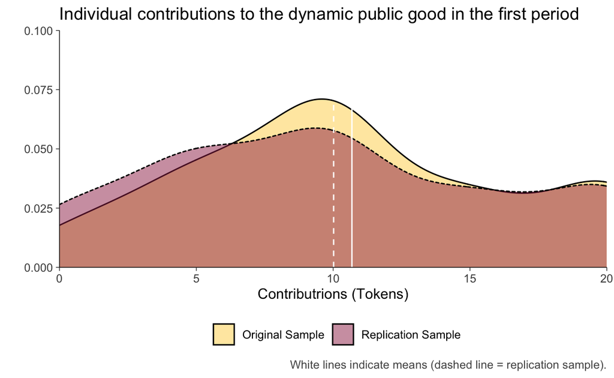

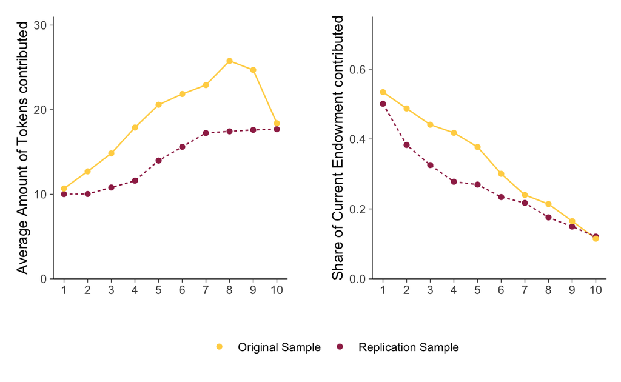

Moreover, both samples’ contributions resemble contributions participants usually make in the standard game with partner matching.[^7] In the dynamic game presented here, different paths lead to different levels of wealth – even if they share the same start- and end-points. We are thus, more interested in the implications contributions have for wealth generation and growth. So, how do the samples compare with respect to wealth/income/endowments/stock?

## Wealth Creation

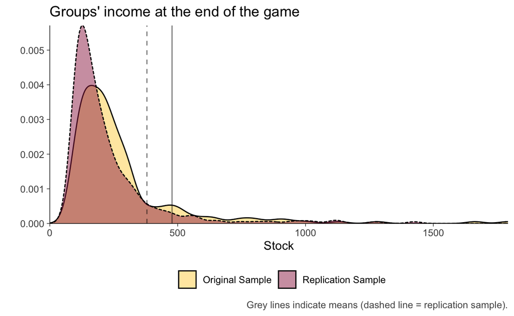

As the grey lines indicate, an average group in the original sample accumulated about 478 tokens. In contrast, an average group in the replication sample accumulated about 380 tokens. However, none of the groups were efficient: the maximal wealth that can be reached in round 10 under full cooperation is approximately 4613 tokens or 230 Euro per group.

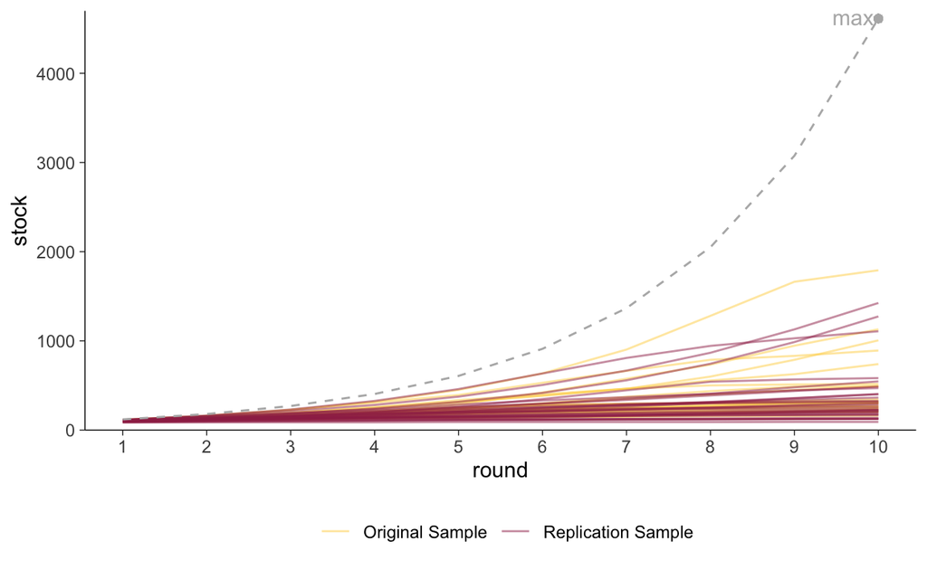

While there is clearly growth, groups do not realize the potential efficiency as the replication groups reach on average a level of 379 tokens out of 4613 maximally possible or 8.2%. As in the original data, there is large heterogeneity with the richest group reaching 1425 tokens whereas the poorest group ends up with 92 tokens.

Figure 2 shows the dynamics of wealth over time.[^10]

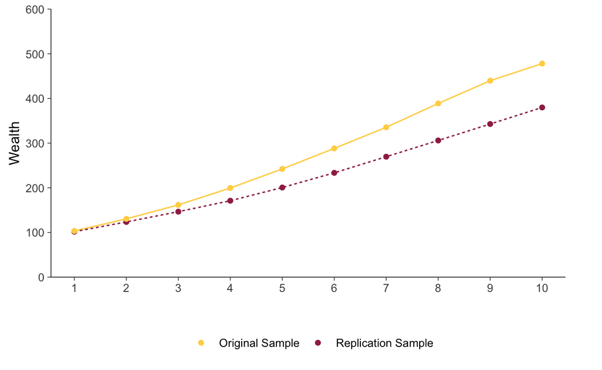

Figure 2: Average wealth over time across treatments.

The Figure illustrates that (in both data sources) growth was continuous and surprisingly linear, given the exponential character of the game’s design.

To sum up, our groups also tend to be poorer, and median wealth is higher in GMTV. The difference in mean ranks is not significant according to a two-sided ranksum test[^11], however.

To further assess the statistical significance of differences in means, we run OLS regressions where we regress wealth on a treatment dummy for *Replication* (Table 3). These regressions show that differences in means are only significant for below median groups. This implies that the poor groups in our data are even less wealthy than GMTV’s poor groups.

|  | *Dependent variable:* |  |  |
| --- | --- | --- | --- |
|  | Wealth |  |  |
|  | All | Below median | Above median |
| Replication | -98.26 | -59.41*** | -138.21 |
|  | (101.21) | (18.32) | (166.67) |
| Constant | 478.09*** | 234.70*** | 731.00*** |
|  | (75.58) | (13.99) | (124.73) |
| Observations | 52 | 24 | 25 |
| R<sup>2</sup> | 0.02 | 0.32 | 0.03 |
| Residual Std. Error | 362.49 | 44.24 | 413.67 |
| *Note:* | p<0.1; p<0.05; p<0.01 |  |  |

## Inequality

In this subsection, we focus on the degree of inequality created endogenously in our setting. The smallest possible value the Gini coefficient takes is zero (if all four group members own one fourth of the wealth) and the largest possible value it takes is one (if one group member holds the entire wealth). Table 4 shows some summary statistics regarding the Gini coefficient.

The round 10 Gini coefficient ranges between 0.035 and 0.52 in our data with a median of 0.218.

| Statistic | replication | GMTV |
| --- | --- | --- |
| Mean | 0.218 | 0.232 |
| Median | 0.218 | 0.233 |
| St. Dev. | 0.123 | 0.123 |
| Max | 0.520 | 0.423 |
| Min | 0.035 | 0.040 |
| N | 29 | 23 |

The two-sided rank sum test yields a p-Value of 0.6059 for the mean `gini` during the last round of the game.

Figure 3 illustrates the dynamics of the Gini coefficient (at the end of each round) over time and shows that inequality increases slightly.

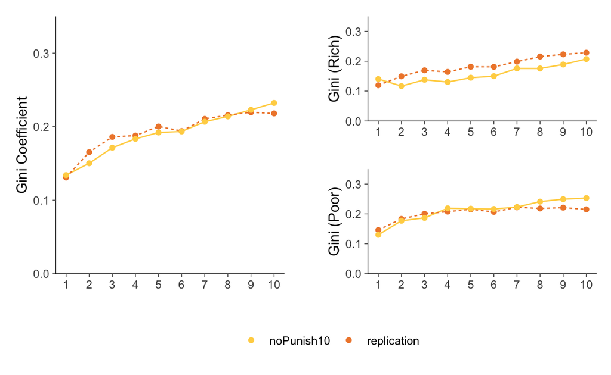

Figure 3: Average Gini coefficient over time across treatments.

### Inequality Differences between Data Sources

Once more, we consider whether we were able to replicate GMTV’s results with our data.

The following table shows a simple OLS regression to illustrate differences in the 10th round’s Gini coefficient between the replication’s data and GMTV’s data. Mean Gini coefficients are similar across data sources and there are no statistically significant differences in mean Gini coefficients.

|  | *Dependent variable:* |  |  |
| --- | --- | --- | --- |
|  | Gini |  |  |
|  | All | Below median | Above median |
| Replication | -0.01 | -0.04 | 0.02 |
|  | (0.03) | (0.05) | (0.05) |
| Constant | 0.23*** | 0.25*** | 0.21*** |
|  | (0.03) | (0.04) | (0.04) |
| Observations | 52 | 24 | 25 |
| R<sup>2</sup> | 0.003 | 0.02 | 0.01 |
| Residual Std. Error | 0.12 | 0.13 | 0.12 |
| *Note:* | p<0.1; p<0.05; p<0.01 |  |  |

# Online Methodology

## Time Spent

Participants spent approximately 24 minutes completing the experiment. Reading the instructions and answering the comprehension questions took the most time, that is, 12 minutes. The public goods game required 7 minutes of the participants’ time.

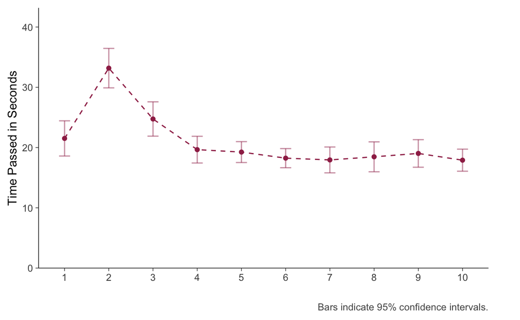

Figure 4: Average Time Spent for each Contribution per Round.

Figure 4 illustrates the time participants needed to make each of their contributions during the replication. One can see that the initial as well as most of the other contributions take about 20 seconds of time. Interestingly, the second contribution takes (on average) about 50% more time than the first one - presumably because this is the first time participants’ learn their respective group members’ actions. The third contribution is a little faster and all subsequent contributions stabilize at 19 seconds.

# Exporatory: Generalizability

Means are indicated by vertical dashed lines and are positive in both settings across samples.[^12] Overall contributions in the VCA setting are smaller than in the experiment’s first round.

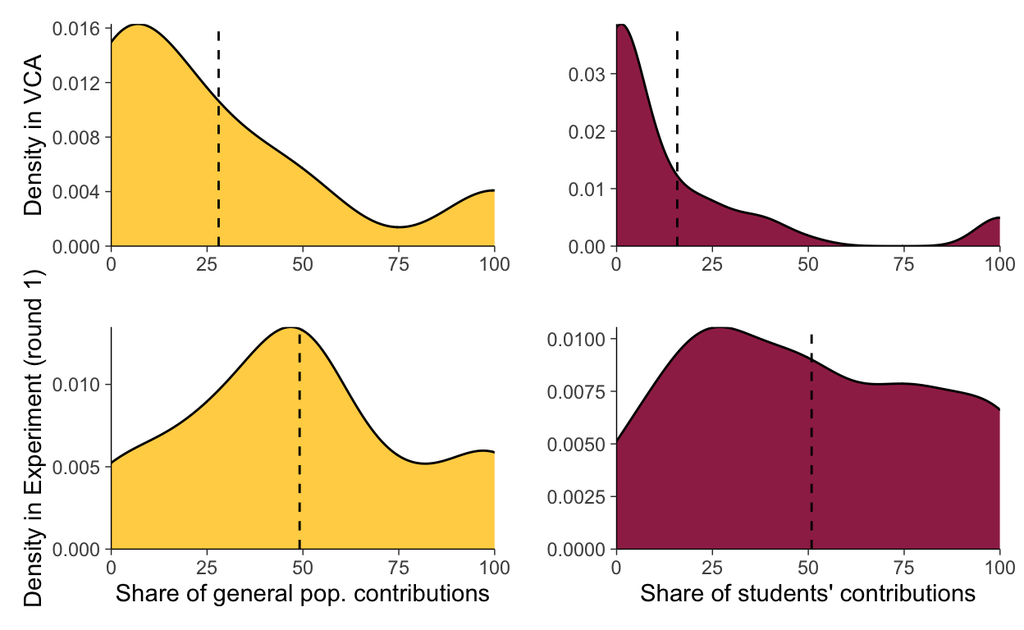

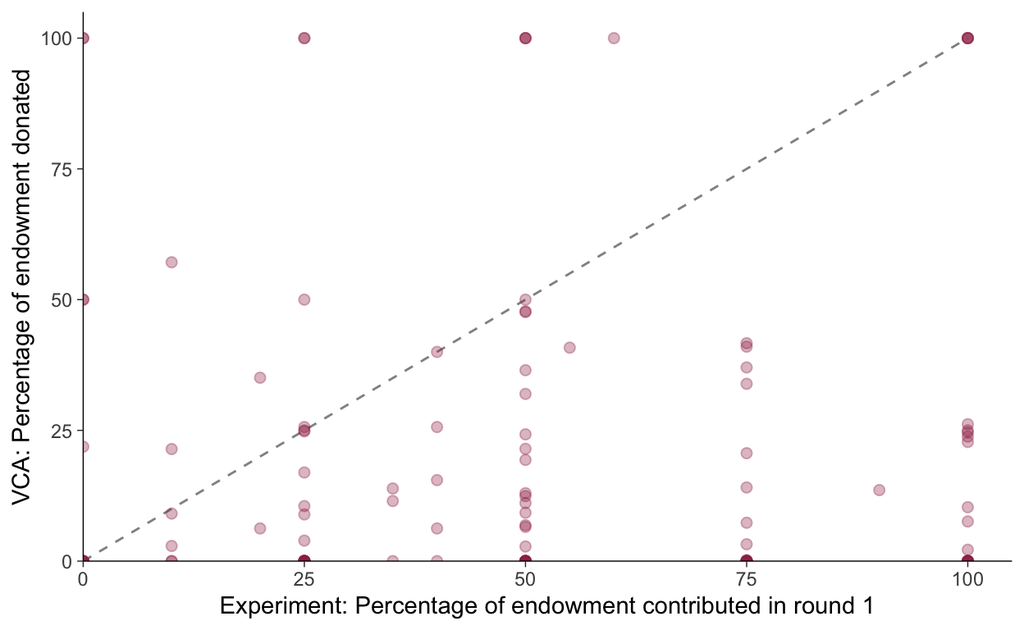

A visual inspection of the scatter plot (where the saturation of the points is proportional to the frequency of a pair of contribution choices) does not hint at an association between the two sorts of contributions.

## To do

- explain similarities and differences to Goeschl et al. (2020) setup and how they came to be
- compare samples across tasks
- who generalizes (better)?
- who is more heterogeneous and what does that mean?
- How do the results compare to Goeschl et al. (2020)

# Conclusion

Arechar, Antonio A, Simon Gächter, and Lucas Molleman. 2018. “Conducting Interactive Experiments Online.” *Experimental Economics* 21 (1): 99–131. https://doi.org/https://doi.org/10.1007/s10683-017-9527-2.

Bem, Daryl J. 1987. “Writing the Empirical Journal Article.” In *The Compleat Academic*, 171–201. Psychology Press. https://doi.org/https://doi.org/10.4324/9781315808314-10.

Berlemann, Michael, Hauke Roggenkamp, and Stefan Traub. 2021. “Replication: Growth and Inequality in Public Good Provision (No-Punish-10) by Gächter Et Al. (2017).” *AEA RCT Registry*. https://doi.org/https://doi.org/10.1257/rct.7902-2.0.

Bock, Olaf, Ingmar Baetge, and Andreas Nicklisch. 2014. “Hroot: Hamburg Registration and Organization Online Tool.” *European Economic Review* 71: 117–20. https://doi.org/https://doi.org/10.1016/j.euroecorev.2014.07.003.

Fehr, Ernst, and Simon Gächter. 2000. “Cooperation and Punishment in Public Goods Experiments.” *American Economic Review* 90 (4): 980–94. https://doi.org/10.1257/aer.90.4.980.

Gächter, Simon, Friederike Mengel, Elias Tsakas, and Alexander Vostroknutov. 2017. “Growth and Inequality in Public Good Provision.” *Journal of Public Economics* 150: 1–13. https://doi.org/10.1016/j.jpubeco.2017.03.002.

Goeschl, Timo, Sara Elisa Kettner, Johannes Lohse, and Christiane Schwieren. 2020. “How Much Can We Learn about Voluntary Climate Action from Behavior in Public Goods Games?” *Ecological Economics* 171: 106591. https://doi.org/https://doi.org/10.1016/j.ecolecon.2020.106591.

[^1]: As well as the option to punish group members.
[^2]: The replication project is registered in the AEA RCT Registry and the unique identifying number is: [AEARCTR-0007902](https://doi.org/10.1257/rct.7902-2.0) (Berlemann, Roggenkamp, and Traub 2021).
[^3]: Taken together with inefficient growth and the lack of dropouts, additional rounds are fairly cheap.
[^4]: Click [here](https://github.com/Howquez/coopUncertainty) to visit the corresponding Github repository.
[^5]: The two-sided rank sum test (comparing differences between samples) yields a p-Value of 0.3926 for the mean contribution in first round of the game.
[^6]: See Figure 3B in Fehr and Gächter (2000) (p.989), for instance.
[^7]: The right panel is thus, comparable to the visualizations *and results* in the standard game. See, for instance, Figure 1B in Fehr and Gächter (2000) (p.986).
[^8]: To measure growth, we define a variable called *stock* which sums the endowments of all participants in a given group at the end of the round (that is, after the contributions have been made, multiplied and redistributed).
[^9]: The two-sided rank sum test (comparing differences between samples) yields a p-Value of 0.1356 for the mean stock in last round of the game.
[^10]: Unlike GMTV I present no median split but only the main results.
[^11]: The two-sided rank sum test (comparing differences between data sources) yields a p-Value of 0.1356 for the mean wealth after the last round of the game.
[^12]: While the medians are similar in the bottom panel, that is, the experiment’s contributions, they are smaller in the taop panel and zero in the student sample.